# ML Final Project

Yolanda Xu

January 25, 2015

It is not uncommon for people to use devices like Jawbone Up, Nike FuelBand and Fitbit to record daily data about personal activity these days. The presented data mainly focus on quantifying how much of a particular activity, but seldom has it quantified how well they do it. From this point, this project aims to use data, which is from accelerometers on the belt, forearm, arm, and dumbell of 6 participants, to quantifying the wellness class and predict the class based on unknown testing data.

The training data for this project are from: https://d396qusza40orc.cloudfront.net/predmachlearn/pml-training.csv And teh test data are from: https://d396qusza40orc.cloudfront.net/predmachlearn/pml-testing.csv

At a first glance of the csv file, there are many NA, white space and #DIV/0! in the data. Thus the first step before preprocessing the data is to identify all these types as NAs and remove columns with much too NAs in the following parts.

```r
#loading
library(caret)
```

```r
library(ggplot2)
library(rpart)
library(rpart.plot)
library(RColorBrewer)
library(rattle)
library(randomForest)
set.seed(12345)

# getting data
training0<-"http://d396qusza40orc.cloudfront.net/predmachlearn/pml-training.csv"
testing0<-"http://d396qusza40orc.cloudfront.net/predmachlearn/pml-testing.csv"
training<-read.csv(url(training0), na.strings=c("NA", " ", "#DIV/0!"))
testing<-read.csv(url(testing0), na.strings=c("NA", " ", "#DIV/0!"))
```

For this medium training datasets, I set p=0.6. So 60% of the data is used for training, and the remaining 40% is used for testing and validation.

```r
# Data Slicing
inTrain<- createDataPartition(y=training$classe, p=0.6, list=FALSE)
mytraining<-training[inTrain, ]
mytesting<-training[-inTrain, ]
```

Besides the outcome classe, there are 159 initial predictors in the dataset. A rough look at data enables one to find that most of the columns are uniformly white space or have few unique values. To remove these near zero variance predictors, I do the following procedures to identify useful predictors.

```r
# preprocessing
DataNZV <- nearZeroVar(mytraining, saveMetrics=TRUE)
DataNZV
```

```
##                          freqRatio percentUnique zeroVar   nzv
## X                         1.000000  1.000000e+02   FALSE FALSE
## user_name                 1.118660  5.095109e-02   FALSE FALSE
## raw_timestamp_part_1      1.037037  7.099185e+00   FALSE FALSE
## raw_timestamp_part_2      1.000000  9.095618e+01   FALSE FALSE
## cvtd_timestamp            1.024664  1.698370e-01   FALSE FALSE
## new_window               49.540773  1.698370e-02   FALSE  TRUE
## num_window                1.037037  7.269022e+00   FALSE FALSE
## roll_belt                 1.187856  8.916440e+00   FALSE FALSE
## pitch_belt                1.103448  1.371433e+01   FALSE FALSE
## yaw_belt                  1.057143  1.436821e+01   FALSE FALSE
## total_accel_belt          1.061385  2.377717e-01   FALSE FALSE
## kurtosis_roll_belt        1.000000  1.944633e+00   FALSE FALSE
## kurtosis_picth_belt       1.000000  1.630435e+00   FALSE FALSE
## kurtosis_yaw_belt         0.000000  0.000000e+00    TRUE  TRUE
## skewness_roll_belt        3.000000  1.927649e+00   FALSE FALSE
## skewness_roll_belt.1      1.500000  1.706861e+00   FALSE FALSE
## skewness_yaw_belt         0.000000  0.000000e+00    TRUE  TRUE
## max_roll_belt             1.333333  1.180367e+00   FALSE FALSE
## max_picth_belt            1.461538  1.783288e-01   FALSE FALSE
## max_yaw_belt              1.000000  4.161005e-01   FALSE FALSE
## min_roll_belt             1.333333  1.061481e+00   FALSE FALSE
## min_pitch_belt            1.909091  1.103940e-01   FALSE FALSE
## min_yaw_belt              1.000000  4.161005e-01   FALSE FALSE
## amplitude_roll_belt       1.222222  8.746603e-01   FALSE FALSE
## amplitude_pitch_belt      3.000000  1.103940e-01   FALSE FALSE
## amplitude_yaw_belt        0.000000  8.491848e-03    TRUE  TRUE
## var_total_accel_belt      1.590909  3.821332e-01   FALSE FALSE
## avg_roll_belt             1.111111  1.112432e+00   FALSE FALSE
## stddev_roll_belt          1.000000  4.161005e-01   FALSE FALSE
## var_roll_belt             1.600000  5.095109e-01   FALSE FALSE
## avg_pitch_belt            1.400000  1.307745e+00   FALSE FALSE
## stddev_pitch_belt         1.272727  2.972147e-01   FALSE FALSE
## var_pitch_belt            1.521739  3.821332e-01   FALSE FALSE
## avg_yaw_belt              1.142857  1.350204e+00   FALSE FALSE
## stddev_yaw_belt           2.208333  3.651495e-01   FALSE FALSE
## var_yaw_belt              1.461538  8.491848e-01   FALSE FALSE
## gyros_belt_x              1.028777  1.052989e+00   FALSE FALSE
## gyros_belt_y              1.156529  5.349864e-01   FALSE FALSE
## gyros_belt_z              1.097396  1.358696e+00   FALSE FALSE
```

[output cut: 106 more lines]

```
## stddev_pitch_forearm     22.000000  1.604959e+00   FALSE  TRUE
## var_pitch_forearm        44.000000  1.613451e+00   FALSE  TRUE
## avg_yaw_forearm          44.000000  1.613451e+00   FALSE  TRUE
## stddev_yaw_forearm       44.000000  1.613451e+00   FALSE  TRUE
## var_yaw_forearm          44.000000  1.613451e+00   FALSE  TRUE
## gyros_forearm_x           1.009346  2.309783e+00   FALSE FALSE
## gyros_forearm_y           1.013636  6.003736e+00   FALSE FALSE
## gyros_forearm_z           1.107266  2.369226e+00   FALSE FALSE
## accel_forearm_x           1.096154  6.598166e+00   FALSE FALSE
## accel_forearm_y           1.158730  8.330503e+00   FALSE FALSE
## accel_forearm_z           1.010753  4.645041e+00   FALSE FALSE
## magnet_forearm_x          1.222222  1.204993e+01   FALSE FALSE
## magnet_forearm_y          1.039216  1.530231e+01   FALSE FALSE
## magnet_forearm_z          1.083333  1.340014e+01   FALSE FALSE
## classe                    1.469065  4.245924e-02   FALSE FALSE
```

```r
NZVvars <- names(mytraining) %in% c("new_window", "kurtosis_roll_belt", "kurtosis_picth_belt",
                                      "kurtosis_yaw_belt", "skewness_roll_belt", "skewness_roll_belt.1", "skewness_yaw_belt",
                                      "max_yaw_belt", "min_yaw_belt", "amplitude_yaw_belt", "avg_roll_arm", "stddev_roll_arm",
                                      "var_roll_arm", "avg_pitch_arm", "stddev_pitch_arm", "var_pitch_arm", "avg_yaw_arm",
                                      "stddev_yaw_arm", "var_yaw_arm", "kurtosis_roll_arm", "kurtosis_picth_arm",
                                      "kurtosis_yaw_arm", "skewness_roll_arm", "skewness_pitch_arm", "skewness_yaw_arm",
                                      "max_roll_arm", "min_roll_arm", "min_pitch_arm", "amplitude_roll_arm", "amplitude_pitch_arm",
                                      "kurtosis_roll_dumbbell", "kurtosis_picth_dumbbell", "kurtosis_yaw_dumbbell", "skewness_roll_dumbbell",
                                      "skewness_pitch_dumbbell", "skewness_yaw_dumbbell", "max_yaw_dumbbell", "min_yaw_dumbbell",
                                      "amplitude_yaw_dumbbell", "kurtosis_roll_forearm", "kurtosis_picth_forearm", "kurtosis_yaw_forearm",
                                      "skewness_roll_forearm", "skewness_pitch_forearm", "skewness_yaw_forearm", "max_roll_forearm",
                                      "max_yaw_forearm", "min_roll_forearm", "min_yaw_forearm", "amplitude_roll_forearm",
                                      "amplitude_yaw_forearm", "avg_roll_forearm", "stddev_roll_forearm", "var_roll_forearm",
                                      "avg_pitch_forearm", "stddev_pitch_forearm", "var_pitch_forearm", "avg_yaw_forearm",
                                      "stddev_yaw_forearm", "var_yaw_forearm")
mytraining <- mytraining[!NZVvars]
mytraining <- mytraining[c(-1)]
dim(mytraining)
```

```
## [1] 11776    99
```

Too many NAs largely injure the columns’ ability to act as good predictors. So next is to remove columns that have much too NAs. The threshold setting here is 60%, which means if there are over 60% elements in one column are NAs, I will disqualify the predictor and remove it from the dataset.

```r
#remove colums that have more than 60% NA
training1 <- mytraining
for(i in 1:length(mytraining)) {
  if( sum( is.na( mytraining[, i] ) ) /nrow(mytraining) >= .6 ) {
    for(j in 1:length(training1)) {
      if( length( grep(names(mytraining[i]), names(training1)[j]) ) ==1)  {
        training1 <- training1[ , -j]
      }
    }
  }
}
mytraining<-training1
rm(training1)
dim(mytraining)
```

```
## [1] 11776    58
```

When I have finished preprocessing with “mytraining” part in the training data, I do the same process with “mytesting” part in the training data and original testing data. It is simple if I copy the name of the predictors directly. Also, I would like to make the data type in “mytesting” and “testing” the same as that in “mytraining”, so that there will be less error when I use the fitted model to do predition.

```r
# for mytesting & testing
clean1 <- colnames(mytraining)
clean2 <- colnames(mytraining[,-58])
mytesting <- mytesting[clean1]
testing <- testing[clean2]

# conversion to enforce the data type in testing is the same as that in mytraining
for (i in 1:length(testing) ) {
  for(j in 1:length(mytraining)) {
    if( length( grep(names(mytraining[i]), names(testing)[j]) ) ==1)  {
      class(testing[j]) <- class(mytraining[i])
    }
  }
}
testing <- rbind(mytraining[2, -58] , testing)
testing <- testing[-1,]
```

Here, I apply two algorithms to do the prediction, one is predicting with trees, and the other is random forests. Generally, random forest method is more accurate than decision tree, because the former involves boostrapping samples. And the fitted models tell the same story if investigating each model using confusionMatrix(). Both accuracy and Kappa values of the ramdon forest model are better than that of decision tree, showing great advantage of random forest.

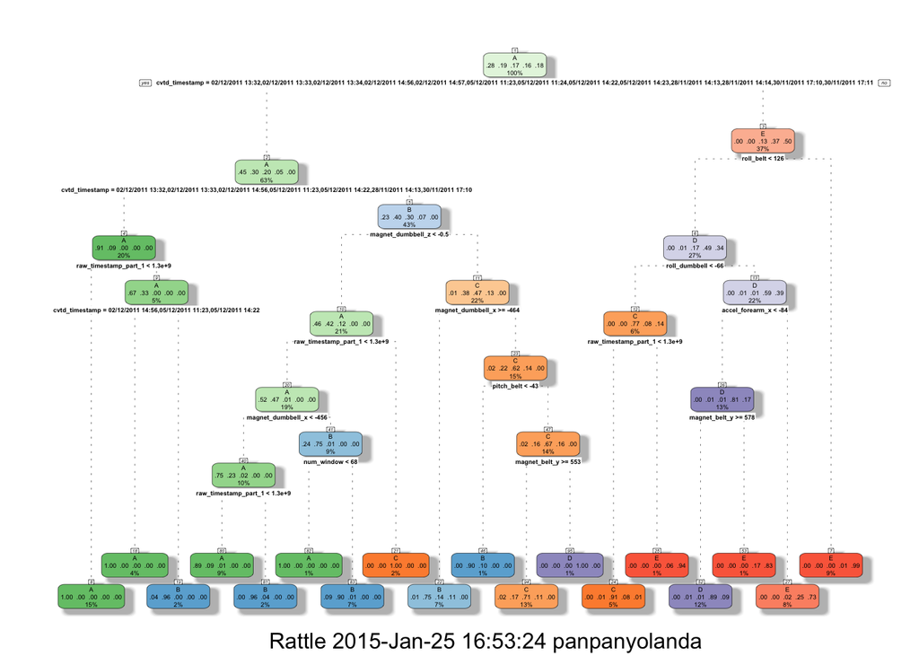

```r
# machine learning # trees
modFit1 <- rpart(classe ~ ., data=mytraining, method="class")
fancyRpartPlot(modFit1)
```

```r
predictmytesting1<-predict(modFit1, mytesting, type="class")
confusionMatrix(predictmytesting1, mytesting$classe)
```

```
## Confusion Matrix and Statistics
##
##           Reference
## Prediction    A    B    C    D    E
##          A 2150   60    7    1    0
##          B   61 1260   69   64    0
##          C   21  188 1269  143    4
##          D    0   10   14  857   78
##          E    0    0    9  221 1360
##
## Overall Statistics
##
##                Accuracy : 0.8789
##                  95% CI : (0.8715, 0.8861)
##     No Information Rate : 0.2845
##     P-Value [Acc > NIR] : < 2.2e-16
##
##                   Kappa : 0.8468
##  Mcnemar's Test P-Value : NA
##
## Statistics by Class:
##
##                      Class: A Class: B Class: C Class: D Class: E
## Sensitivity            0.9633   0.8300   0.9276   0.6664   0.9431
## Specificity            0.9879   0.9693   0.9450   0.9845   0.9641
## Pos Pred Value         0.9693   0.8666   0.7809   0.8936   0.8553
## Neg Pred Value         0.9854   0.9596   0.9841   0.9377   0.9869
## Prevalence             0.2845   0.1935   0.1744   0.1639   0.1838
## Detection Rate         0.2740   0.1606   0.1617   0.1092   0.1733
## Detection Prevalence   0.2827   0.1853   0.2071   0.1222   0.2027
## Balanced Accuracy      0.9756   0.8997   0.9363   0.8254   0.9536
```

```r
# machine learning # random forest
modFit2<-randomForest(classe~.,data=mytraining)
predictmytesting2<-predict(modFit2, mytesting, type="class")
confusionMatrix(predictmytesting2, mytesting$classe)
```

```
## Confusion Matrix and Statistics
##
##           Reference
## Prediction    A    B    C    D    E
##          A 2231    2    0    0    0
##          B    1 1516    2    0    0
##          C    0    0 1366    3    0
##          D    0    0    0 1282    2
##          E    0    0    0    1 1440
##
## Overall Statistics
##
##                Accuracy : 0.9986
##                  95% CI : (0.9975, 0.9993)
##     No Information Rate : 0.2845
##     P-Value [Acc > NIR] : < 2.2e-16
##
##                   Kappa : 0.9982
##  Mcnemar's Test P-Value : NA
##
## Statistics by Class:
##
##                      Class: A Class: B Class: C Class: D Class: E
## Sensitivity            0.9996   0.9987   0.9985   0.9969   0.9986
## Specificity            0.9996   0.9995   0.9995   0.9997   0.9998
## Pos Pred Value         0.9991   0.9980   0.9978   0.9984   0.9993
## Neg Pred Value         0.9998   0.9997   0.9997   0.9994   0.9997
## Prevalence             0.2845   0.1935   0.1744   0.1639   0.1838
## Detection Rate         0.2843   0.1932   0.1741   0.1634   0.1835
## Detection Prevalence   0.2846   0.1936   0.1745   0.1637   0.1837
## Balanced Accuracy      0.9996   0.9991   0.9990   0.9983   0.9992
```

In this case, I use the second model to do prediction here.

```r
# predicting
predictesting <- predict(modFit2, testing, type = "class")
predictesting
```

```
##  2 31  4  5  6  7  8  9 10 11 12 13 14 15 16 17 18 19 20 21
##  B  A  B  A  A  E  D  B  A  A  B  C  B  A  E  E  A  B  B  B
## Levels: A B C D E
```

The above vector shown in predictesting is corresponding to the prediction from problem_id 1 to problem_id 20.